# COM747 Week 4: Regression and Time Series Analysis

Lecture demonstrations and complete seminar solutions

> **How to use this notebook.** Part A follows the lecture slides in order. Part B works through every task on the seminar sheet (`exercise(3).pdf` and the time-series tutorial), with comments explaining *why* each line is there. Put `rundata.csv`, `nybirths.dat` and `titanic.csv` in the same folder as this file.

```r
# Packages used this week. Install once per computer with install.packages("name").
library(psych)      # pairs.panels(): scatterplot matrix with correlations
library(TTR)        # SMA(): simple moving average
library(tseries)    # adf.test(): stationarity test
library(forecast)   # auto.arima(), forecast(), accuracy()
library(survival)   # Surv(), survfit(): Kaplan-Meier survival curves
```

# Part A: Lecture demonstrations

## 1. Correlation

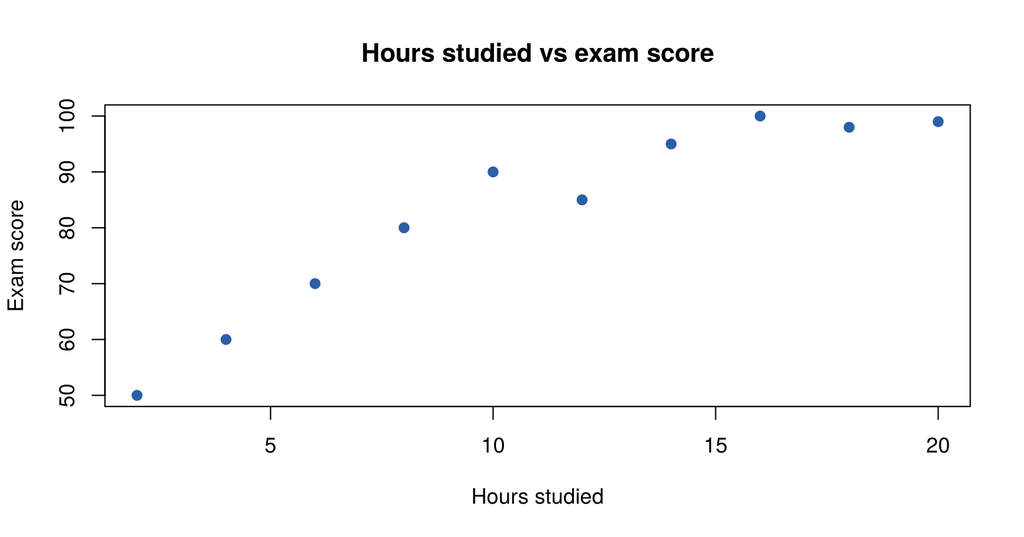

```r
# Example from class: hours studied vs exam score for 10 students
hours_studied <- c(2, 4, 6, 8, 10, 12, 14, 16, 18, 20)
exam_scores   <- c(50, 60, 70, 80, 90, 85, 95, 100, 98, 99)

plot(hours_studied, exam_scores, pch = 19, col = "#2b5fa6",
     xlab = "Hours studied", ylab = "Exam score", main = "Hours studied vs exam score")
```

```r
# Pearson: strength of the LINEAR relationship; assumes roughly normal data
cor(hours_studied, exam_scores, method = "pearson")
```

```
## [1] 0.9395411
```

```r
cor.test(hours_studied, exam_scores, method = "pearson")   # H0: true correlation = 0
```

```
##
##  Pearson's product-moment correlation
##
## data:  hours_studied and exam_scores
## t = 7.7603, df = 8, p-value = 5.432e-05
## alternative hypothesis: true correlation is not equal to 0
## 95 percent confidence interval:
##  0.7587763 0.9859305
## sample estimates:
##       cor
## 0.9395411
```

```r
# Spearman uses ranks, so it suits ordinal data (like a job rank) and skewed data
employee_rank    <- c(1, 2, 3, 4, 5, 6, 7, 8, 9, 10)
job_satisfaction <- c(5, 7, 8, 6, 9, 10, 8, 7, 9, 10)
cor(employee_rank, job_satisfaction, method = "spearman")
```

```
## [1] 0.6564911
```

```r
cor.test(employee_rank, job_satisfaction, method = "spearman", exact = FALSE)
```

```
##
##  Spearman's rank correlation rho
##
## data:  employee_rank and job_satisfaction
## S = 56.679, p-value = 0.03922
## alternative hypothesis: true rho is not equal to 0
## sample estimates:
##       rho
## 0.6564911
```

```r
cor(employee_rank, job_satisfaction, method = "kendall")   # Kendall's tau: good for small samples
```

```
## [1] 0.5354632
```

**Correlation is not causation.** A third (confounding) variable can drive both. Always ask *what else could explain this?*

### Anscombe’s quartet: why we always plot

```r
# Four datasets with (almost) identical summary statistics
sapply(1:4, function(i) round(c(mean_x = mean(anscombe[[paste0("x", i)]]),
                                 mean_y = mean(anscombe[[paste0("y", i)]]),
                                 r      = cor(anscombe[[paste0("x", i)]], anscombe[[paste0("y", i)]])), 2))
```

```
##        [,1] [,2] [,3] [,4]
## mean_x 9.00 9.00 9.00 9.00
## mean_y 7.50 7.50 7.50 7.50
## r      0.82 0.82 0.82 0.82
```

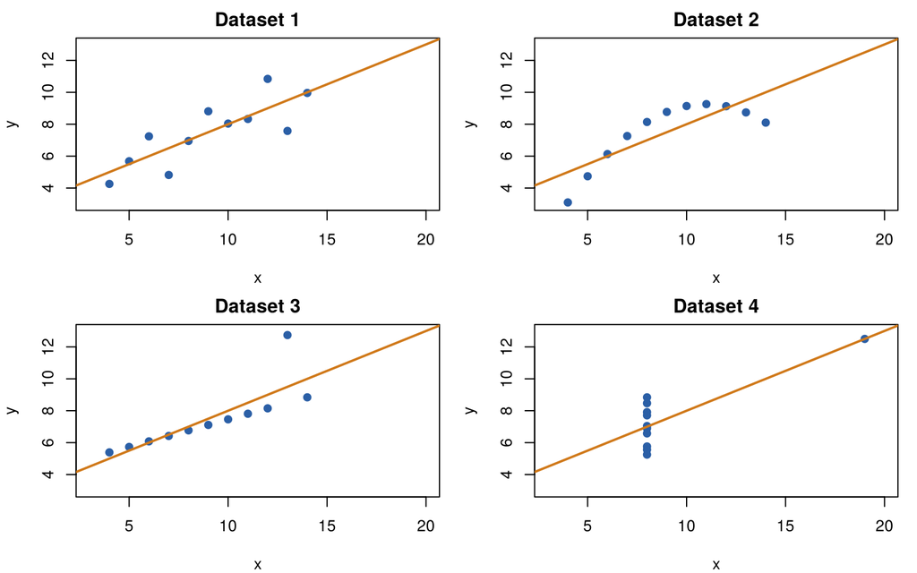

```r
par(mfrow = c(2, 2), mar = c(4, 4, 2, 1))
for (i in 1:4) {
  x <- anscombe[[paste0("x", i)]]; y <- anscombe[[paste0("y", i)]]
  plot(x, y, pch = 19, col = "#2b5fa6", main = paste("Dataset", i), xlim = c(3, 20), ylim = c(3, 13))
  abline(lm(y ~ x), col = "#d0791a", lwd = 2)
}
```

```r
par(mfrow = c(1, 1))
```

## 2. Simple linear regression

```r
model <- lm(exam_scores ~ hours_studied)   # read "~" as "is modelled by"
summary(model)
```

```
##
## Call:
## lm(formula = exam_scores ~ hours_studied)
##
## Residuals:
##     Min      1Q  Median      3Q     Max
## -8.2364 -3.7136  0.2364  4.0364 10.0182
##
## Coefficients:
##               Estimate Std. Error t value Pr(>|t|)
## (Intercept)    52.8000     4.3467   12.15 1.95e-06 ***
## hours_studied   2.7182     0.3503    7.76 5.43e-05 ***
## ---
## Signif. codes:  0 '***' 0.001 '**' 0.01 '*' 0.05 '.' 0.1 ' ' 1
##
## Residual standard error: 6.363 on 8 degrees of freedom
## Multiple R-squared:  0.8827, Adjusted R-squared:  0.8681
## F-statistic: 60.22 on 1 and 8 DF,  p-value: 5.432e-05
```

```r
# Intercept (b0): predicted score with 0 hours of study
# Slope (b1):     extra marks for each additional hour
coef(model)
```

```
##   (Intercept) hours_studied
##     52.800000      2.718182
```

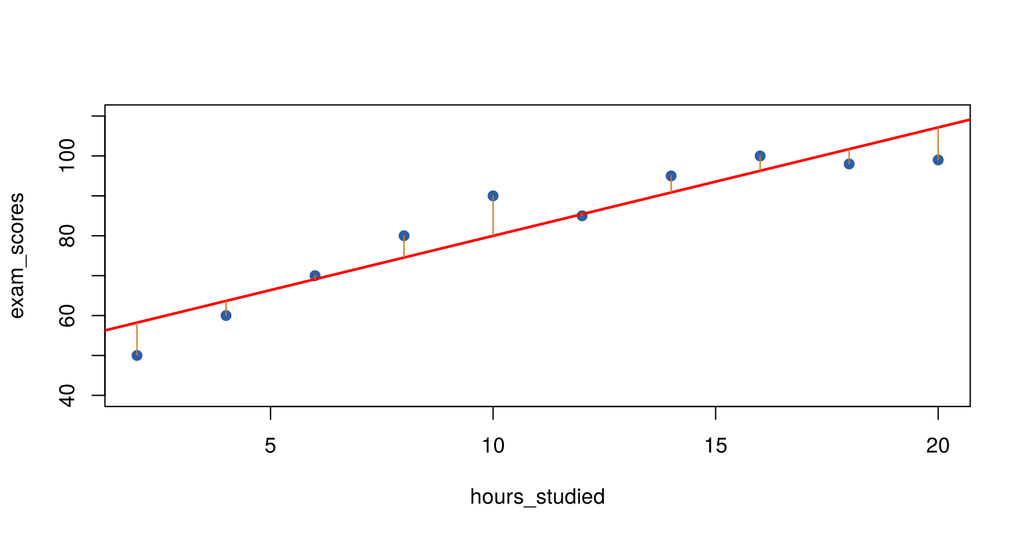

```r
plot(hours_studied, exam_scores, pch = 19, col = "#2b5fa6", ylim = c(40, 110))
abline(model, col = "red", lwd = 2)
# draw the residuals: observed minus predicted
segments(hours_studied, exam_scores, hours_studied, fitted(model), col = "#d0791a")
```

```r
# Goodness of fit
residuals(model)                    # e = y - y_hat
```

```
##          1          2          3          4          5          6          7
## -8.2363636 -3.6727273  0.8909091  5.4545455 10.0181818 -0.4181818  4.1454545
##          8          9         10
##  3.7090909 -3.7272727 -8.1636364
```

```r
sum(residuals(model)^2)             # the quantity OLS minimises
```

```
## [1] 323.8909
```

```r
summary(model)$r.squared            # proportion of variance explained
```

```
## [1] 0.8827374
```

```r
cor(hours_studied, exam_scores)^2   # for ONE predictor, R-squared = r squared
```

```
## [1] 0.8827374
```

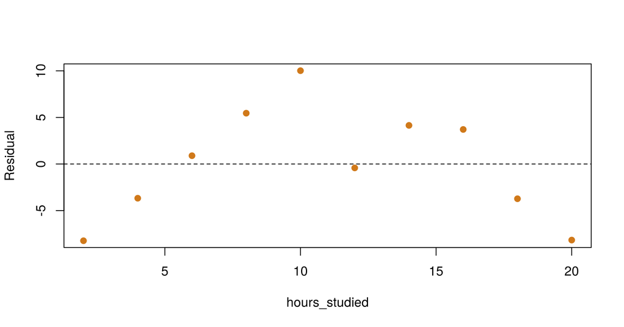

```r
# Residual plot: look for random scatter around 0 (no curve, no funnel)
plot(hours_studied, residuals(model), pch = 19, col = "#d0791a", ylab = "Residual")
abline(h = 0, lty = 2)
```

**Ask:** The residuals go negative at both ends and positive in the middle. What does that suggest? (The relationship levels off: a curve may fit better.)

```r
# A curved (quadratic) model: add hours squared as an extra feature
model2 <- lm(exam_scores ~ hours_studied + I(hours_studied^2))
summary(model2)$adj.r.squared   # compare with the straight line
```

```
## [1] 0.9699248
```

```r
summary(model)$adj.r.squared
```

```
## [1] 0.8680796
```

## 3. Simpson’s paradox

```r
# Kidney stone data (Charig et al., 1986): successes / patients
stones <- data.frame(
  treatment = rep(c("A open surgery", "B nephrolithotomy"), each = 2),
  size      = rep(c("small", "large"), 2),
  success   = c(81, 192, 234, 55),
  patients  = c(87, 263, 270, 80))
stones$rate <- round(stones$success / stones$patients, 3)
stones
```

```
##           treatment  size success patients  rate
## 1    A open surgery small      81       87 0.931
## 2    A open surgery large     192      263 0.730
## 3 B nephrolithotomy small     234      270 0.867
## 4 B nephrolithotomy large      55       80 0.688
```

```r
# Combined over stone size:
aggregate(cbind(success, patients) ~ treatment, data = stones, sum) |>
  transform(rate = round(success / patients, 3))
```

```
##           treatment success patients  rate
## 1    A open surgery     273      350 0.780
## 2 B nephrolithotomy     289      350 0.826
```

```r
# A is better within EACH size group, but B looks better overall,
# because A was used more often on the harder large stones (a confounder).
```

# Part B: Seminar exercises (complete solutions)

## Exercise 1: correlations in the iris data

```r
# The sheet asks you to download iris from Kaggle; it is also built into R.
# iris <- read.csv("Iris.csv")   # Kaggle version (columns SepalLengthCm, etc.)
data(iris)
cor.test(iris$Sepal.Length, iris$Sepal.Width, method = "pearson")
```

```
##
##  Pearson's product-moment correlation
##
## data:  iris$Sepal.Length and iris$Sepal.Width
## t = -1.4403, df = 148, p-value = 0.1519
## alternative hypothesis: true correlation is not equal to 0
## 95 percent confidence interval:
##  -0.27269325  0.04351158
## sample estimates:
##        cor
## -0.1175698
```

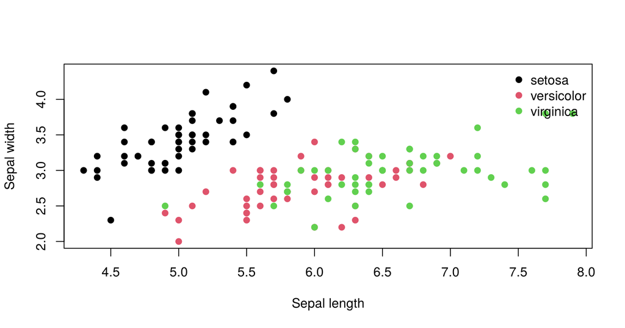

```r
plot(iris$Sepal.Length, iris$Sepal.Width, pch = 19, col = iris$Species,
     xlab = "Sepal length", ylab = "Sepal width")
legend("topright", levels(iris$Species), col = 1:3, pch = 19, bty = "n")
```

**Interpretation.** Overall r = −0.12 (p = 0.15): a weak, non-significant negative relationship. But colour the points by species and *within each species* the relationship is clearly positive (0.74, 0.53, 0.46). Mixing three species hides it: another example of Simpson’s paradox.

```r
sapply(split(iris, iris$Species), function(d) round(cor(d$Sepal.Length, d$Sepal.Width), 2))
```

```
##     setosa versicolor  virginica
##       0.74       0.53       0.46
```

```r
# Correlation (adjacency) matrix: every pair at once
round(cor(iris[c("Sepal.Length", "Sepal.Width", "Petal.Length", "Petal.Width")]), 2)
```

```
##              Sepal.Length Sepal.Width Petal.Length Petal.Width
## Sepal.Length         1.00       -0.12         0.87        0.82
## Sepal.Width         -0.12        1.00        -0.43       -0.37
## Petal.Length         0.87       -0.43         1.00        0.96
## Petal.Width          0.82       -0.37         0.96        1.00
```

**What do they mean?** Petal length and petal width are almost perfectly related (r = 0.96); both are strongly related to sepal length (0.87, 0.82). Sepal width is weakly *negatively* related to the others. For modelling, the petal measurements carry nearly the same information, so using both adds little (multicollinearity).

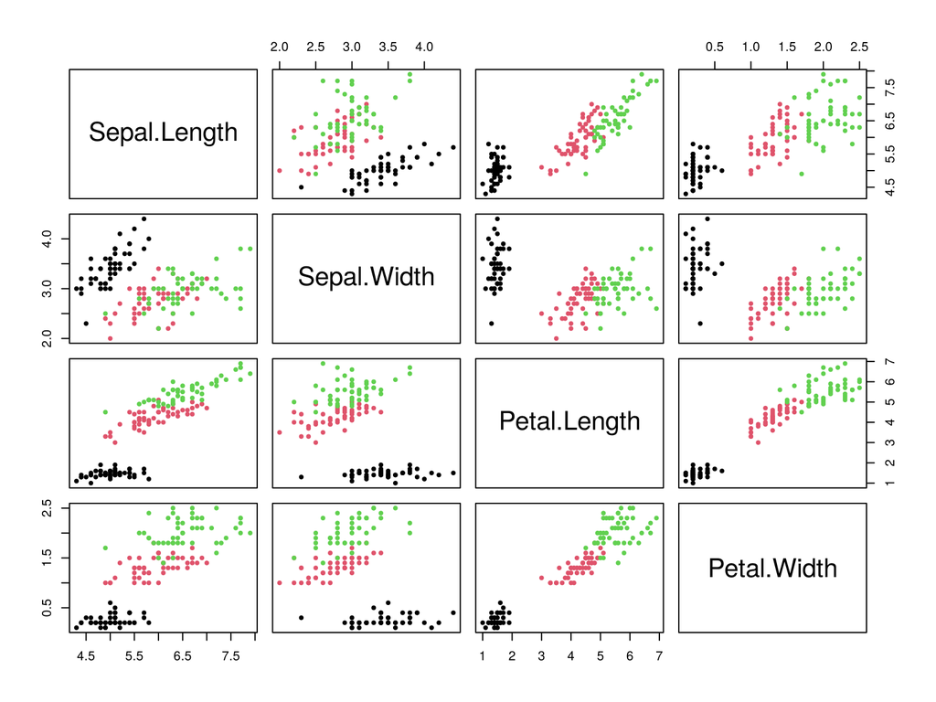

```r
pairs(iris[c("Sepal.Length", "Sepal.Width", "Petal.Length", "Petal.Width")],
      col = iris$Species, pch = 19, cex = 0.6)
```

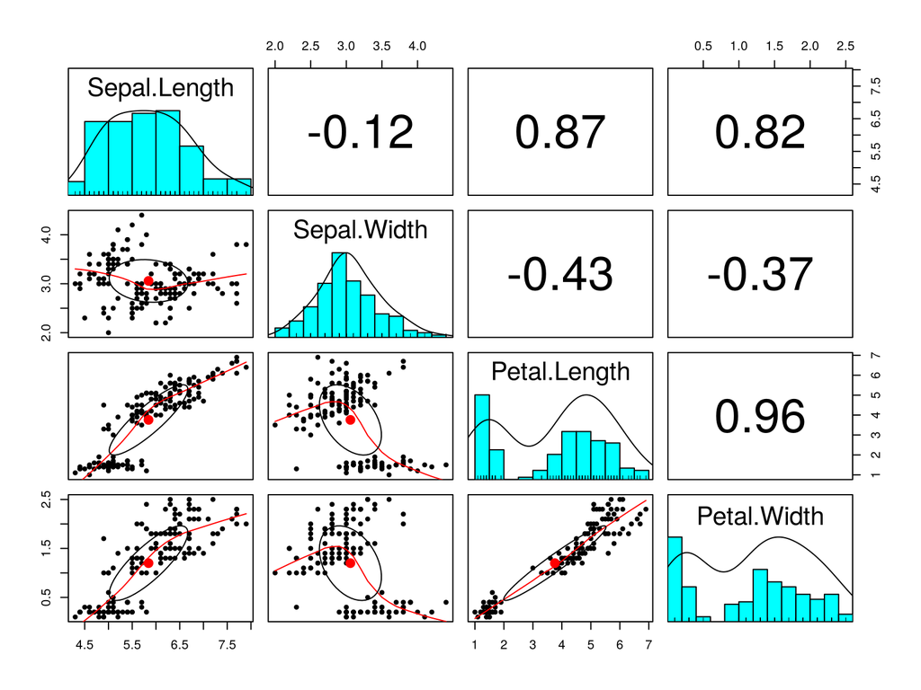

```r
pairs.panels(iris[c("Sepal.Length", "Sepal.Width", "Petal.Length", "Petal.Width")])
```

**Summary paragraph (as the sheet asks).** The scatterplot matrix shows strong positive linear relationships between petal length, petal width and sepal length (r between 0.82 and 0.96), with the points falling into clear clusters that correspond to the three species. Sepal width is only weakly and negatively correlated with the other measurements overall. The histograms on the diagonal show that the petal measurements are bimodal (setosa is much smaller than the other two species), so Pearson correlations here partly reflect the species differences rather than one smooth relationship.

## Exercise 2: regression on rundata

```r
rundata <- read.csv("rundata.csv")
str(rundata)
```

```
## 'data.frame':    99 obs. of  3 variables:
##  $ FirstRun : num  7.47 24.16 35.06 30.71 31.03 ...
##  $ SecondRun: num  11.2 29.2 41.8 34 37.6 ...
##  $ FinalRun : num  23.4 38.9 47.9 40.4 41 ...
```

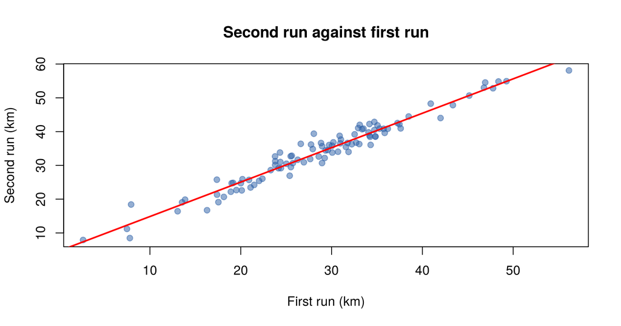

```r
plot(rundata$FirstRun, rundata$SecondRun, pch = 19, col = "#2b5fa680",
     xlab = "First run (km)", ylab = "Second run (km)")
reg1 <- lm(SecondRun ~ FirstRun, data = rundata)   # same as lm(rundata$SecondRun ~ rundata$FirstRun)
abline(reg1, col = "red", lwd = 2)
title("Second run against first run")
```

```r
cor(rundata$FirstRun, rundata$SecondRun)        # 0.976
```

```
## [1] 0.9762012
```

```r
cor.test(rundata$FirstRun, rundata$SecondRun)   # p < 2.2e-16: significant
```

```
##
##  Pearson's product-moment correlation
##
## data:  rundata$FirstRun and rundata$SecondRun
## t = 44.333, df = 97, p-value < 2.2e-16
## alternative hypothesis: true correlation is not equal to 0
## 95 percent confidence interval:
##  0.9647003 0.9839856
## sample estimates:
##       cor
## 0.9762012
```

### Multiple regression: predict the final run from the first two

```r
lma <- lm(FinalRun ~ FirstRun + SecondRun, data = rundata)
summary(lma)
```

```
##
## Call:
## lm(formula = FinalRun ~ FirstRun + SecondRun, data = rundata)
##
## Residuals:
##     Min      1Q  Median      3Q     Max
## -6.4895 -1.6483  0.1199  1.6938 10.5144
##
## Coefficients:
##             Estimate Std. Error t value Pr(>|t|)
## (Intercept)   5.5375     1.1337   4.884 4.14e-06 ***
## FirstRun     -0.2783     0.1427  -1.951    0.054 .
## SecondRun     1.2866     0.1367   9.412 2.73e-15 ***
## ---
## Signif. codes:  0 '***' 0.001 '**' 0.01 '*' 0.05 '.' 0.1 ' ' 1
##
## Residual standard error: 2.92 on 96 degrees of freedom
## Multiple R-squared:  0.9261, Adjusted R-squared:  0.9245
## F-statistic: 601.1 on 2 and 96 DF,  p-value: < 2.2e-16
```

```r
car::vif(lma)   # Variance inflation factor: ~21 here, far above the usual 5-10 warning level
```

```
##  FirstRun SecondRun
##  21.26247  21.26247
```

```r
# Predict the final run for a new runner who ran 22 km and then 25 km
newdata <- data.frame(FirstRun = 22, SecondRun = 25)
predict(lma, newdata)
```

```
##        1
## 31.57917
```

```r
predict(lma, newdata, interval = "prediction")   # a 95% range for ONE new runner
```

```
##        fit      lwr      upr
## 1 31.57917 25.71252 37.44581
```

### Train / test evaluation

```r
set.seed(12345)                                  # makes the shuffle reproducible
run2 <- rundata[order(runif(99)), ]             # random order: runif gives 99 random numbers, order() ranks them
lma_train <- lm(FinalRun ~ FirstRun + SecondRun, data = run2[1:80, ])   # 80 runners to TRAIN
testing   <- run2[81:99, ]                                              # 19 unseen runners to TEST
predictions <- predict(lma_train, testing)
```

```r
diff     <- predictions - testing$FinalRun   # positive = over-prediction
diff_ABS <- abs(diff)

mean(diff)              # bias: close to 0, so no systematic over/under-prediction
```

```
## [1] -0.05874524
```

```r
mean(diff_ABS)          # MAE: average miss in km
```

```
## [1] 1.81249
```

```r
sqrt(mean(diff^2))      # RMSE: penalises big misses more
```

```
## [1] 2.491515
```

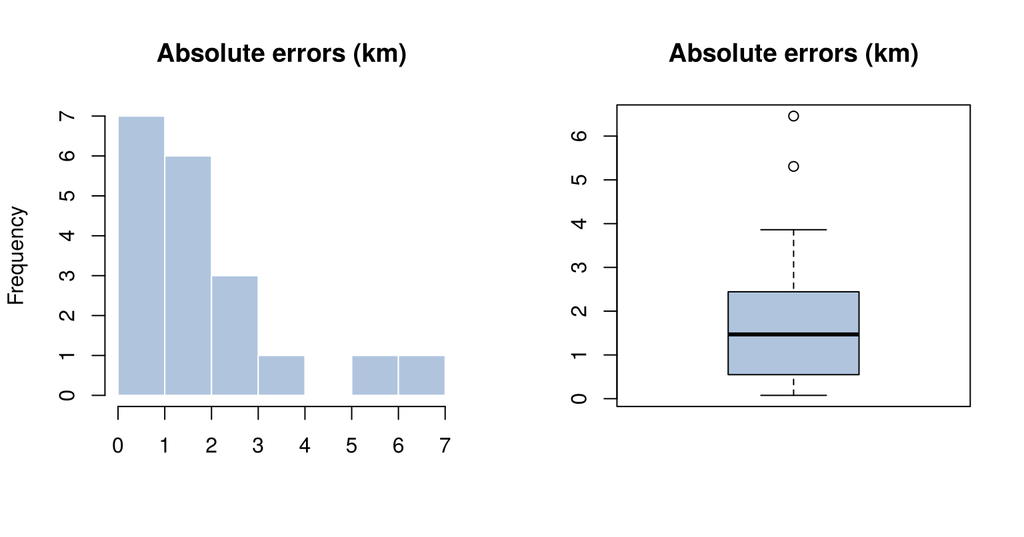

```r
par(mfrow = c(1, 2))
hist(diff_ABS, col = "lightsteelblue", border = "white", main = "Absolute errors (km)", xlab = "")
boxplot(diff_ABS, col = "lightsteelblue", main = "Absolute errors (km)")
```

```r
par(mfrow = c(1, 1))

length(diff[diff > 0])           # how many predictions were HIGHER than the real distance?
```

```
## [1] 11
```

```r
length(diff_ABS[diff_ABS <= 2])  # how many were within 2 km?
```

```
## [1] 13
```

```r
testing$prediction <- round(predictions, 2)
testing$difference <- round(diff_ABS, 2)
head(testing)    # the two new columns the slides show
```

```
##    FirstRun SecondRun FinalRun prediction difference
## 92    21.08     23.46    28.67      29.64       0.97
## 87    25.39     26.94    38.10      32.79       5.31
## 52    28.05     39.38    47.76      48.99       1.23
## 37    31.58     35.45    42.11      42.19       0.08
## 81    13.87     19.86    25.96      27.44       1.48
## 2     24.16     29.16    38.91      36.34       2.57
```

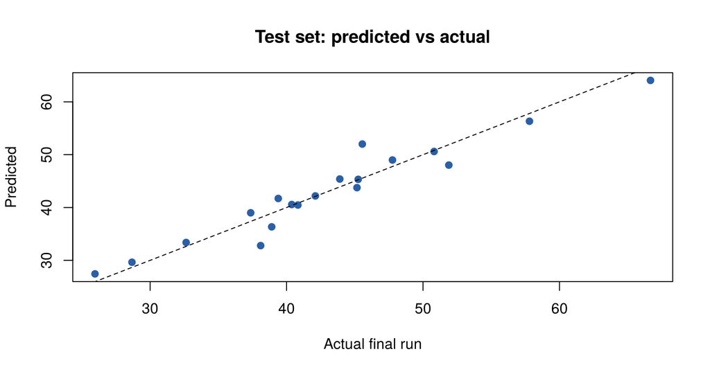

```r
plot(testing$FinalRun, testing$prediction, pch = 19, col = "#2b5fa6",
     xlab = "Actual final run", ylab = "Predicted", main = "Test set: predicted vs actual")
abline(0, 1, lty = 2)   # perfect predictions fall on this line
```

The lecture task says “build using 70%, test on 30%”. The slide code uses 80/19. A true 70/30 split is `run2[1:69, ]` for training and `run2[70:99, ]` for testing; try both and compare the MAE.

```r
lm70 <- lm(FinalRun ~ FirstRun + SecondRun, data = run2[1:69, ])
mean(abs(predict(lm70, run2[70:99, ]) - run2$FinalRun[70:99]))   # MAE with a 70/30 split
```

```
## [1] 1.667719
```

## Exercise 3: logistic regression

```r
# Binary target: 1 if the final run was 45 km or more
rundata$superrun <- ifelse(rundata$FinalRun >= 45, 1, 0)
table(rundata$superrun)   # 64 no, 35 yes
```

```
##
##  0  1
## 64 35
```

```r
logitModel <- glm(superrun ~ FirstRun + SecondRun, data = rundata,
                  family = binomial(link = "logit"))
summary(logitModel)
```

```
##
## Call:
## glm(formula = superrun ~ FirstRun + SecondRun, family = binomial(link = "logit"),
##     data = rundata)
##
## Coefficients:
##             Estimate Std. Error z value Pr(>|z|)
## (Intercept) -31.2903     7.7446  -4.040 5.34e-05 ***
## FirstRun     -0.1479     0.2119  -0.698  0.48512
## SecondRun     0.9541     0.3020   3.160  0.00158 **
## ---
## Signif. codes:  0 '***' 0.001 '**' 0.01 '*' 0.05 '.' 0.1 ' ' 1
##
## (Dispersion parameter for binomial family taken to be 1)
##
##     Null deviance: 128.622  on 98  degrees of freedom
## Residual deviance:  36.464  on 96  degrees of freedom
## AIC: 42.464
##
## Number of Fisher Scoring iterations: 8
```

```r
exp(coef(logitModel))                                    # odds ratios
```

```
##  (Intercept)     FirstRun    SecondRun
## 2.575155e-14 8.624775e-01 2.596426e+00
```

```r
exp(cbind(OR = coef(logitModel), confint(logitModel)))   # with 95% confidence intervals
```

```
##                       OR        2.5 %       97.5 %
## (Intercept) 2.575155e-14 2.003145e-22 6.492420e-09
## FirstRun    8.624775e-01 5.509512e-01 1.288707e+00
## SecondRun   2.596426e+00 1.574955e+00 5.327193e+00
```

**Interpretation.** The odds ratio for SecondRun is about 2.6 (95% CI 1.6 to 5.3): each extra km on the second run multiplies the odds of a super run by 2.6. The interval does not include 1, so the effect is significant. FirstRun’s OR (0.86) has an interval that includes 1: no independent effect once SecondRun is known.

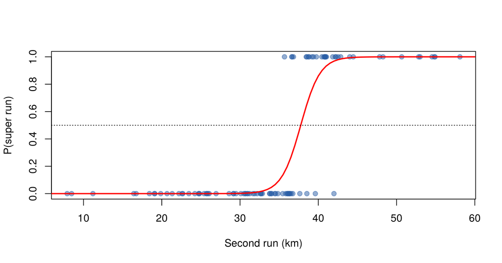

```r
# Visualise with one predictor so we can draw the S-shaped curve
m1 <- glm(superrun ~ SecondRun, data = rundata, family = binomial)
plot(rundata$SecondRun, rundata$superrun, pch = 19, col = "#2b5fa680",
     xlab = "Second run (km)", ylab = "P(super run)")
xs <- seq(5, 60, by = 0.5)
lines(xs, predict(m1, data.frame(SecondRun = xs), type = "response"), col = "red", lwd = 2)
abline(h = 0.5, lty = 3)
```

```r
# Turn probabilities into classes and check the confusion matrix (training data)
p_hat <- predict(logitModel, type = "response")
pred  <- ifelse(p_hat > 0.5, 1, 0)
table(actual = rundata$superrun, predicted = pred)
```

```
##       predicted
## actual  0  1
##      0 60  4
##      1  4 31
```

```r
mean(pred == rundata$superrun)   # accuracy on the training data (optimistic)
```

```
## [1] 0.9191919
```

## Exercise 4: Titanic survival

```r
titanic <- read.csv("titanic.csv")
str(titanic)
```

```
## 'data.frame':    891 obs. of  12 variables:
##  $ PassengerId: int  1 2 3 4 5 6 7 8 9 10 ...
##  $ Survived   : int  0 1 1 1 0 0 0 0 1 1 ...
##  $ Pclass     : int  3 1 3 1 3 3 1 3 3 2 ...
##  $ Name       : chr  "Braund, Mr. Owen Harris" "Cumings, Mrs. John Bradley (Florence Briggs Thayer)" "Heikkinen, Miss. Laina" "Futrelle, Mrs. Jacques Heath (Lily May Peel)" ...
##  $ Sex        : chr  "male" "female" "female" "female" ...
##  $ Age        : num  22 38 26 35 35 NA 54 2 27 14 ...
##  $ SibSp      : int  1 1 0 1 0 0 0 3 0 1 ...
##  $ Parch      : int  0 0 0 0 0 0 0 1 2 0 ...
##  $ Ticket     : chr  "A/5 21171" "PC 17599" "STON/O2. 3101282" "113803" ...
##  $ Fare       : num  7.25 71.28 7.92 53.1 8.05 ...
##  $ Cabin      : chr  "" "C85" "" "C123" ...
##  $ Embarked   : chr  "S" "C" "S" "S" ...
```

```r
colSums(is.na(titanic))           # Age has 177 missing values
```

```
## PassengerId    Survived      Pclass        Name         Sex         Age
##           0           0           0           0           0         177
##       SibSp       Parch      Ticket        Fare       Cabin    Embarked
##           0           0           0           0           0           0
```

```r
titanic$Pclass <- factor(titanic$Pclass)   # class is a category, not a number
titanic$Sex    <- factor(titanic$Sex)

tm <- glm(Survived ~ Pclass + Sex + Age + SibSp, data = titanic, family = binomial)
summary(tm)                       # rows with missing Age are dropped (714 used)
```

```
##
## Call:
## glm(formula = Survived ~ Pclass + Sex + Age + SibSp, family = binomial,
##     data = titanic)
##
## Coefficients:
##              Estimate Std. Error z value Pr(>|z|)
## (Intercept)  4.334201   0.450700   9.617  < 2e-16 ***
## Pclass2     -1.414360   0.284727  -4.967 6.78e-07 ***
## Pclass3     -2.652618   0.285832  -9.280  < 2e-16 ***
## Sexmale     -2.627679   0.214771 -12.235  < 2e-16 ***
## Age         -0.044760   0.008225  -5.442 5.27e-08 ***
## SibSp       -0.380190   0.121516  -3.129  0.00176 **
## ---
## Signif. codes:  0 '***' 0.001 '**' 0.01 '*' 0.05 '.' 0.1 ' ' 1
##
## (Dispersion parameter for binomial family taken to be 1)
##
##     Null deviance: 964.52  on 713  degrees of freedom
## Residual deviance: 636.56  on 708  degrees of freedom
##   (177 observations deleted due to missingness)
## AIC: 648.56
##
## Number of Fisher Scoring iterations: 5
```

```r
round(exp(coef(tm)), 3)
```

```
## (Intercept)     Pclass2     Pclass3     Sexmale         Age       SibSp
##      76.264       0.243       0.070       0.072       0.956       0.684
```

```r
# Honest evaluation: train on 70%, test on 30%
t2 <- titanic[!is.na(titanic$Age), ]          # simple approach: drop rows with missing Age
set.seed(1)
idx   <- sample(nrow(t2), round(0.7 * nrow(t2)))
train <- t2[idx, ]; test <- t2[-idx, ]
tm2   <- glm(Survived ~ Pclass + Sex + Age + SibSp, data = train, family = binomial)
prob  <- predict(tm2, test, type = "response")
pred  <- ifelse(prob > 0.5, 1, 0)
table(actual = test$Survived, predicted = pred)
```

```
##       predicted
## actual   0   1
##      0 101  18
##      1  33  62
```

```r
mean(pred == test$Survived)                   # test accuracy
```

```
## [1] 0.7616822
```

## Exercise 5: time series (NY births)

```r
# The lecture reads the data from the web:
# births <- scan("http://robjhyndman.com/tsdldata/data/nybirths.dat")
births <- scan("nybirths.dat")                 # same data, saved locally
birthstimeseries <- ts(births, frequency = 12, start = c(1946, 1))
birthstimeseries
```

```
##         Jan    Feb    Mar    Apr    May    Jun    Jul    Aug    Sep    Oct
## 1946 26.663 23.598 26.931 24.740 25.806 24.364 24.477 23.901 23.175 23.227
## 1947 21.439 21.089 23.709 21.669 21.752 20.761 23.479 23.824 23.105 23.110
## 1948 21.937 20.035 23.590 21.672 22.222 22.123 23.950 23.504 22.238 23.142
## 1949 21.548 20.000 22.424 20.615 21.761 22.874 24.104 23.748 23.262 22.907
## 1950 22.604 20.894 24.677 23.673 25.320 23.583 24.671 24.454 24.122 24.252
## 1951 23.287 23.049 25.076 24.037 24.430 24.667 26.451 25.618 25.014 25.110
## 1952 23.798 22.270 24.775 22.646 23.988 24.737 26.276 25.816 25.210 25.199
## 1953 24.364 22.644 25.565 24.062 25.431 24.635 27.009 26.606 26.268 26.462
## 1954 24.657 23.304 26.982 26.199 27.210 26.122 26.706 26.878 26.152 26.379
## 1955 24.990 24.239 26.721 23.475 24.767 26.219 28.361 28.599 27.914 27.784
## 1956 26.217 24.218 27.914 26.975 28.527 27.139 28.982 28.169 28.056 29.136
## 1957 26.589 24.848 27.543 26.896 28.878 27.390 28.065 28.141 29.048 28.484
## 1958 27.132 24.924 28.963 26.589 27.931 28.009 29.229 28.759 28.405 27.945
## 1959 26.076 25.286 27.660 25.951 26.398 25.565 28.865 30.000 29.261 29.012
##         Nov    Dec
## 1946 21.672 21.870
## 1947 21.759 22.073
## 1948 21.059 21.573
## 1949 21.519 22.025
## 1950 22.084 22.991
## 1951 22.964 23.981
## 1952 23.162 24.707
## 1953 25.246 25.180
## 1954 24.712 25.688
## 1955 25.693 26.881
## 1956 26.291 26.987
## 1957 26.634 27.735
## 1958 25.912 26.619
## 1959 26.992 27.897
```

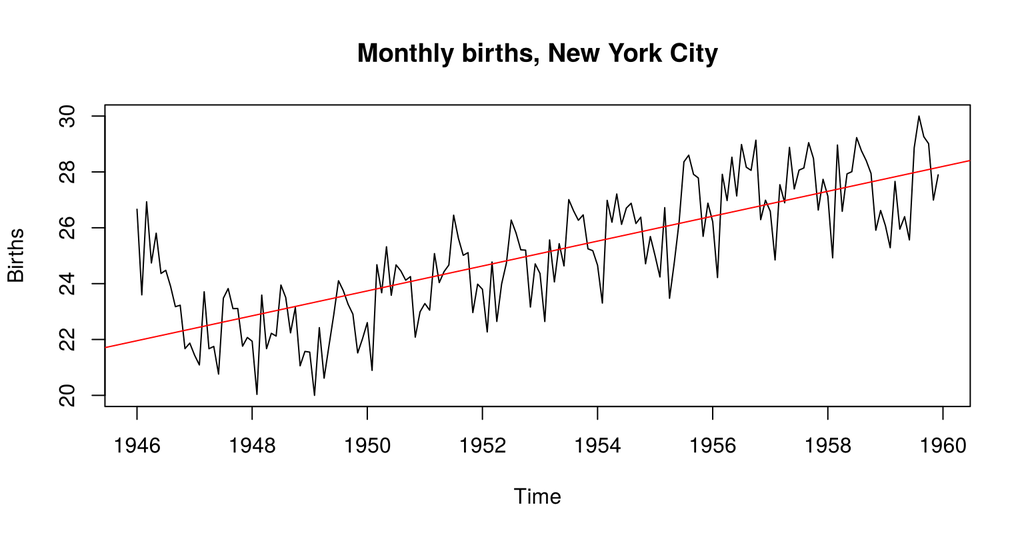

```r
plot.ts(birthstimeseries, ylab = "Births", main = "Monthly births, New York City")
abline(reg = lm(birthstimeseries ~ time(birthstimeseries)), col = "red")   # linear trend
```

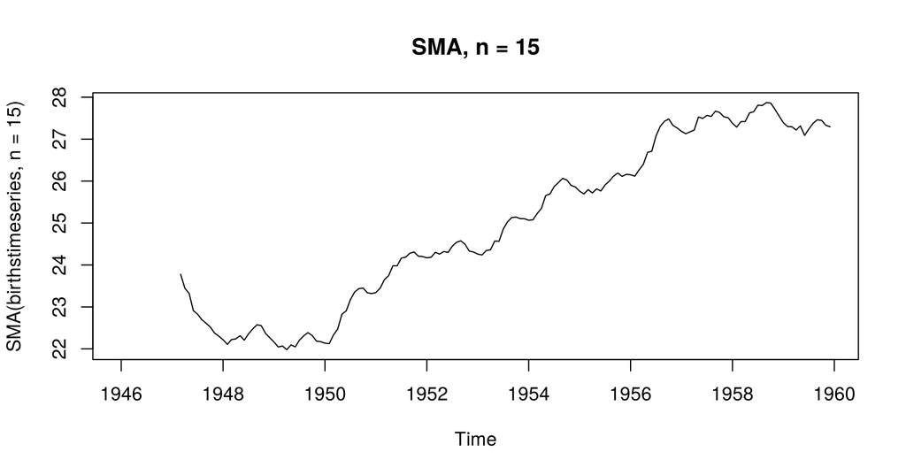

```r
# Simple moving average: mean of the last n months smooths out the noise
plot.ts(SMA(birthstimeseries, n = 15), main = "SMA, n = 15")
```

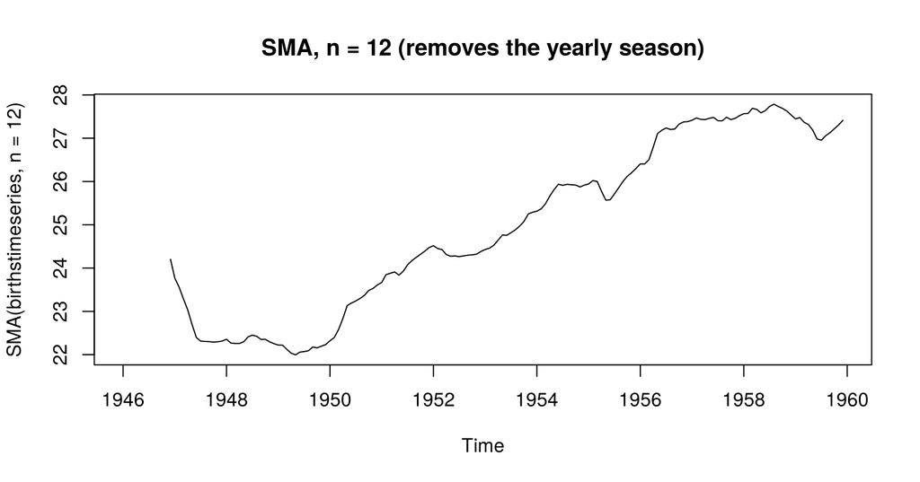

```r
plot.ts(SMA(birthstimeseries, n = 12), main = "SMA, n = 12 (removes the yearly season)")
```

The slide overwrites `birthstimeseries` with its SMA (`birthstimeseries <- SMA(...)`). That loses the original data and the `ts` attributes, so every later step runs on smoothed data. Store it under a new name instead, as above.

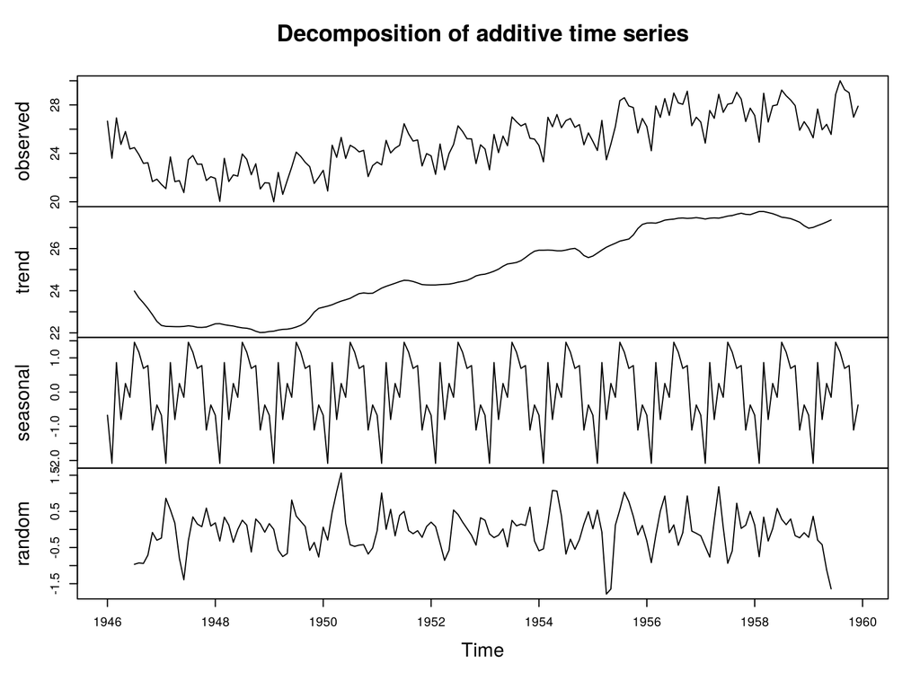

```r
birthstimeseriescomponents <- decompose(birthstimeseries)
plot(birthstimeseriescomponents)
```

```r
round(birthstimeseriescomponents$figure, 2)   # seasonal effect for Jan..Dec
```

```
##  [1] -0.68 -2.08  0.86 -0.80  0.25 -0.15  1.46  1.16  0.69  0.78 -1.11 -0.38
```

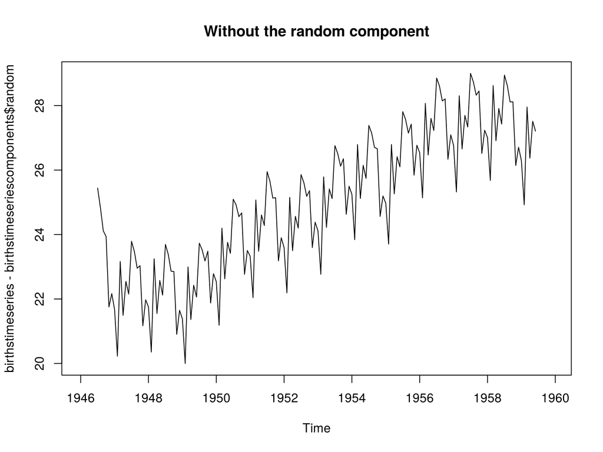

```r
# Remove the random part (keeps trend + season)
plot.ts(birthstimeseries - birthstimeseriescomponents$random, main = "Without the random component")
```

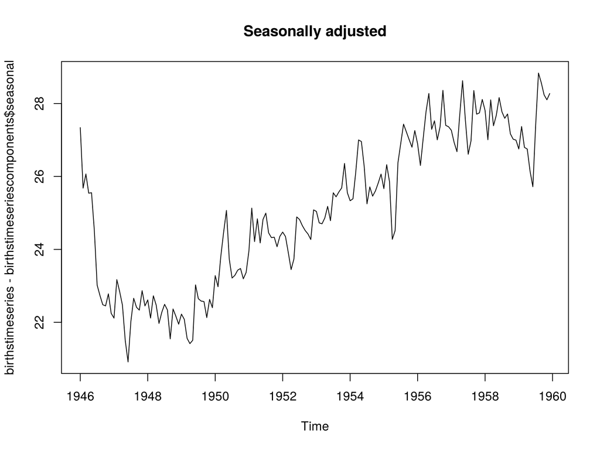

```r
# Seasonally adjusted (removes the season, keeps trend + noise)
plot.ts(birthstimeseries - birthstimeseriescomponents$seasonal, main = "Seasonally adjusted")
```

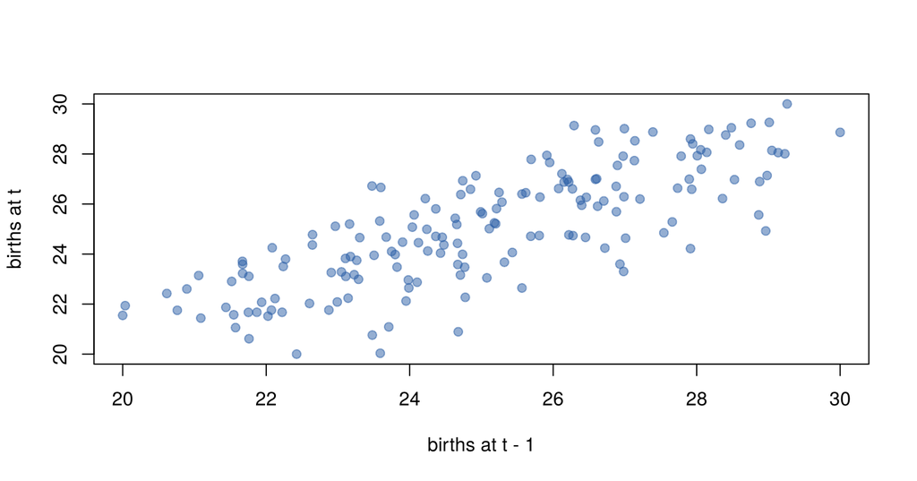

```r
# Lag-1 autocorrelation by hand: each month against the month before
plot(birthstimeseries[2:168], birthstimeseries[1:167], pch = 19, col = "#2b5fa680",
     xlab = "births at t - 1", ylab = "births at t")
```

```r
cor(birthstimeseries[2:168], birthstimeseries[1:167])   # 0.788
```

```
## [1] 0.7880606
```